# Geospatial Carpentry: Session 1: Intro to R

# [Data frame Manipulation with dplyr](https://datacarpentry.org/r-intro-geospatial/06-dplyr/index.html) (30+10 min)

## Packages

So far, we have been using functionalities available with R installation. Now, that we would like to move forward with our analysis, we can make use of packages - add-on sets of functions that need to be explicitly activated. Now, we will be using `tidyverse` package, which is actually a collection of useful packages.

If you have have not installed this package earlier, please do so. You can check if you have it installed in the the ’Packages pane in the bottom-right window.

```r
install.packages('tidyverse')
```

You need to install package only once, but you will need to load it each time you want to use its functionalities. To do that you use `library()` command:

```r
library('tidyverse')
```

## Select

Let’s start manipulating the data.

First we will adapt our dataset, by keeping only the columns we’re interested in using the `select()` function from `dplyr` package:

```r
year_country_gdp <- select(gapminder, year, country, gdpPercap)

head(year_country_gdp)
```

```
##   year     country gdpPercap
## 1 1952 Afghanistan  779.4453
## 2 1957 Afghanistan  820.8530
## 3 1962 Afghanistan  853.1007
## 4 1967 Afghanistan  836.1971
## 5 1972 Afghanistan  739.9811
## 6 1977 Afghanistan  786.1134
```

## Pipe

Now, this is not the most common notation when working with `dplyr` package. `dplyr` offers an operator `%>%` called a pipe, which allows you build up a very complicated commands in a readable way.

The `select()` statement with pipe would look like that:

```r
year_country_gdp <- gapminder %>% select(year,country,gdpPercap)

head(year_country_gdp)
```

```
##   year     country gdpPercap
## 1 1952 Afghanistan  779.4453
## 2 1957 Afghanistan  820.8530
## 3 1962 Afghanistan  853.1007
## 4 1967 Afghanistan  836.1971
## 5 1972 Afghanistan  739.9811
## 6 1977 Afghanistan  786.1134
```

First we define data set, then with the use of pipe we pass it on to the `select()` function. This way we can chain multiple functions together, which we will be doing now.

## Filter

We already now how to select only the needed columns. But now, we also want to filter the data set via certain condition with `filter()` function. Instead doing it in separate steps , we can do it all together. In the `gapminder` data set, we want to see the results only for Europe.

```r
year_country_gdp_euro <- gapminder %>%
  filter(continent == "Europe") %>%
  select(year, country, gdpPercap)
```

### Challenge 5

Write a single command (which can span multiple lines and includes pipes) that will produce a dataframe that has the African values for life expectancy, country and year, but not for other Continents. How many rows does your dataframe have and why?

## Group and summarize

So far, we have created a dataset for one of the continents represented in the `gapminder` dataset. But rather than doing that, we want to know statistics about all of the continents, presented by group.

```r
gapminder %>% # select the dataset
  group_by(continent) %>% # group by continent
  summarize(mean_gdpPercap = mean(gdpPercap)) # summarize function creates statistics for the data set
```

```
## # A tibble: 5 × 2
##   continent mean_gdpPercap
##   <chr>              <dbl>
## 1 Africa             2194.
## 2 Americas           7136.
## 3 Asia               7902.
## 4 Europe            14469.
## 5 Oceania           18622.
```

### Challenge 6

Calculate the average life expectancy per country. Which has the longest average life expectancy and which has the shortest average life expectancy?

You can group by multiple columns:

```r
gapminder %>%
  group_by(continent, year) %>%
  summarize(mean_gdpPercap = mean(gdpPercap))
```

```
## # A tibble: 60 × 3
## # Groups:   continent [5]
##    continent  year mean_gdpPercap
##    <chr>     <int>          <dbl>
##  1 Africa     1952          1253.
##  2 Africa     1957          1385.
##  3 Africa     1962          1598.
##  4 Africa     1967          2050.
##  5 Africa     1972          2340.
##  6 Africa     1977          2586.
##  7 Africa     1982          2482.
##  8 Africa     1987          2283.
##  9 Africa     1992          2282.
## 10 Africa     1997          2379.
## # … with 50 more rows
```

On top of this, you can also make multiple summaries of those groups:

```r
gdp_pop_bycontinents_byyear <- gapminder %>%
  group_by(continent,year) %>%
  summarize(
    mean_gdpPercap = mean(gdpPercap),
    sd_gdpPercap = sd(gdpPercap),
    mean_pop = mean(pop),
    sd_pop = sd(pop)
    )
```

## Frequencies

If you need a number of observations per group, you can use the `count()` function

```r
gapminder %>%
    group_by(continent) %>%
    count()
```

```
## # A tibble: 5 × 2
## # Groups:   continent [5]
##   continent     n
##   <chr>     <int>
## 1 Africa      624
## 2 Americas    300
## 3 Asia        396
## 4 Europe      360
## 5 Oceania      24
```

Sometimes you need the number of observations per group for your calculations. You can use `n()` function for this.

```r
gapminder %>%
    group_by(continent) %>%
    summarize(
      n = n(),
      se_le = sd( lifeExp )/sqrt( n() )
      )
```

```
## # A tibble: 5 × 3
##   continent     n se_le
##   <chr>     <int> <dbl>
## 1 Africa      624 0.366
## 2 Americas    300 0.540
## 3 Asia        396 0.596
## 4 Europe      360 0.286
## 5 Oceania      24 0.775
```

## Mutate

Frequently you’ll want to create new columns based on the values in existing columns, for example to do unit conversions, or to find the ratio of values in two columns. For this we’ll use `mutate()`.

```r
gapminder_gdp <- gapminder %>%
  mutate(gdp_billion = gdpPercap*pop/10^9)

head(gapminder_gdp)
```

```
##       country year      pop continent lifeExp gdpPercap gdp_billion
## 1 Afghanistan 1952  8425333      Asia  28.801  779.4453    6.567086
## 2 Afghanistan 1957  9240934      Asia  30.332  820.8530    7.585449
## 3 Afghanistan 1962 10267083      Asia  31.997  853.1007    8.758856
## 4 Afghanistan 1967 11537966      Asia  34.020  836.1971    9.648014
## 5 Afghanistan 1972 13079460      Asia  36.088  739.9811    9.678553
## 6 Afghanistan 1977 14880372      Asia  38.438  786.1134   11.697659
```

# [Introduction to Visualisation](https://datacarpentry.org/r-intro-geospatial/07-plot-ggplot2/index.html) (20+15 min)

Package `ggplot2` is a powerful plotting system. I will introduce key features of `ggplot`. Later today/ on Monday you will use this package to visualize geospatial data. `gg` stands for grammar of graphics, the idea that three components needed to create a graph are: - data - aesthetics - coordinate system on which we map the data ( what is represented on x axis, what on y axis) - geometries - visual representation of the data (points, bars, etc.)

fun part about `ggplot` is that you can then add additional layers to the plot providing more information and make it more beautiful.

First, lets plot distribution of life expectancy in the `gapminder` dataset.

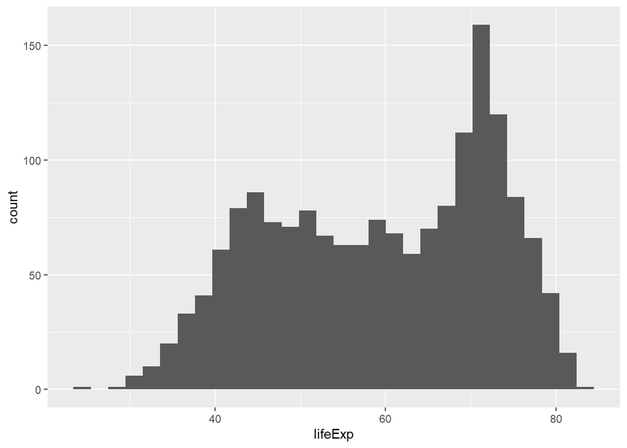

```r
gapminder %>%  # data layer
  ggplot( aes(x = lifeExp)) + # aesthetics layer
  geom_histogram() # geometry layer
```

You can see that in `ggplot` you use `+` as a pipe, to add layers. Within `ggplot` call, it is the only pipe that will work. But, it is possible to chain operations on a dataset with a pipe that we have already learned: `%>%` ( or `|>`) and follow them but ggplot grammar.

Let’s create another plot, this time only on a subset of observations:

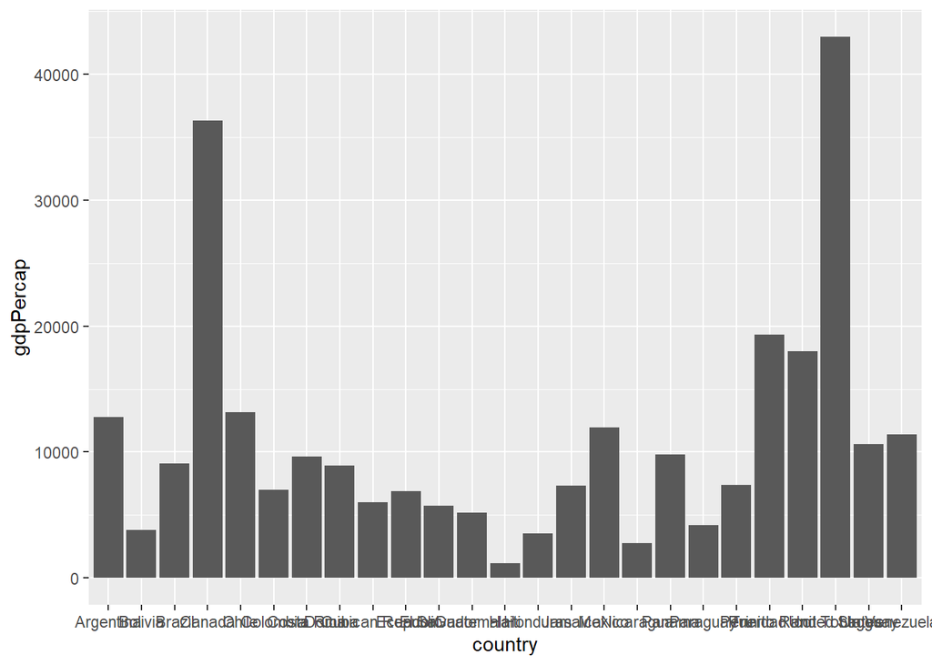

```r
gapminder %>%  # we select a dataset
  filter(year == 2007,
         continent == 'Americas') %>% # and filter it to keep only one year and one continent
  ggplot(aes(x = country, y = gdpPercap)) + # we create aesthetics, both x and y axis represent values of  columns
  geom_col() # we select a column graph as a geometry
```

Now, you can iteratively improve how the plot looks. For example, you might want to flip it, to better display the labels.

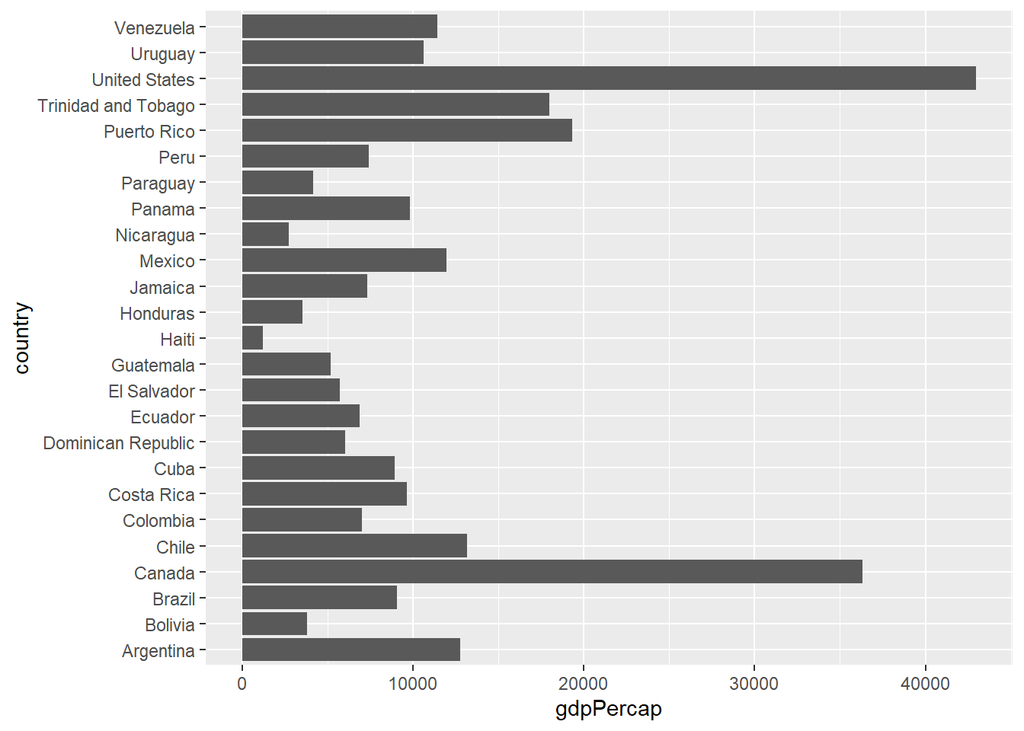

```r
gapminder %>%
  filter(year == 2007,
         continent == 'Americas') %>%
  ggplot(aes(x = country, y = gdpPercap)) +
  geom_col()+
  coord_flip()
```

One thing you might want to change here is the order in which countries are displayed. It would be easier to compare GDP per capita, if theY were showed in order. To do that, we need to reorder factor levels (you remember, we’ve already done this before). the order of the levels will depend on another variable - GDP per capita.

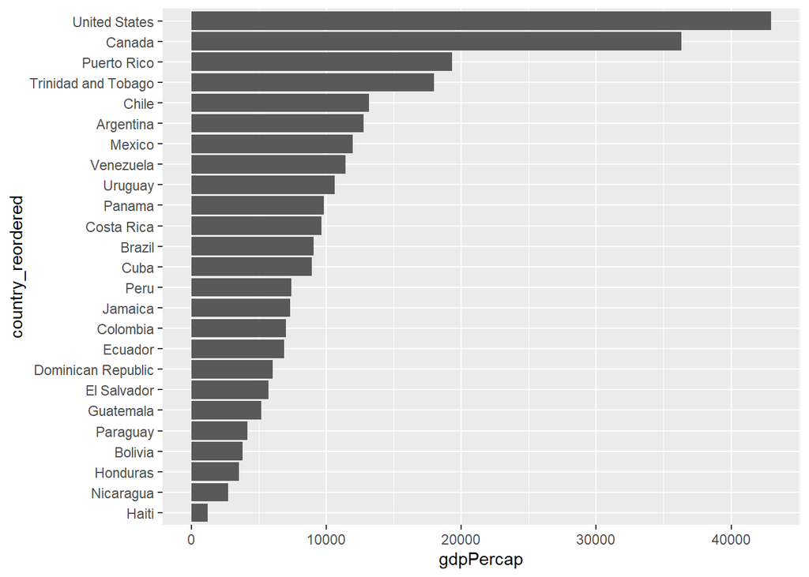

```r
gapminder %>%
  filter(year == 2007,
         continent == 'Americas') %>%
  mutate(country_reordered = fct_reorder(country, gdpPercap )) %>%
  ggplot(aes(x = country_reordered , y = gdpPercap)) +
  geom_col() +
  coord_flip()
```

Let’s make things more colorful - let’s represent the average life expectancy of a country by color

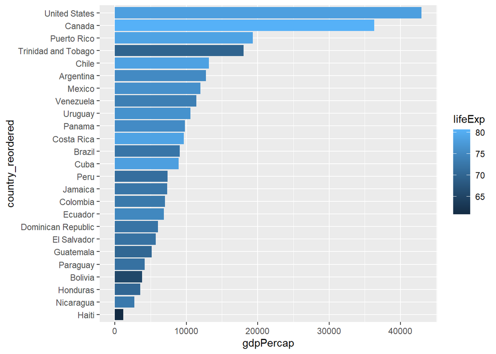

```r
gapminder %>%
  filter(year == 2007,
         continent == 'Americas') %>%
  mutate(country_reordered = fct_reorder(country, gdpPercap )) %>%
  ggplot(aes(x = country_reordered, y = gdpPercap, fill = lifeExp   )) + # fill argument for coloring surfaces, color for points and lines
  geom_col()+
  coord_flip()
```

We can also adapt the color scale. Common choice that is used for its colorblind-proofness is `viridis` package.

```r
plot_2007_amr <-  # this time let's save the plot in the object.
  gapminder %>%
  filter(year == 2007,
         continent == 'Americas') %>%
  mutate(country_reordered = fct_reorder(country, gdpPercap )) %>%
  ggplot(aes(x = country_reordered, y = gdpPercap, fill = lifeExp   )) + # fill argument for coloring surfaces, color for points and lines
  geom_col()+
  coord_flip()+
  scale_fill_viridis_c()
```

Since we saved a plot as an object, nothing has been printed out. Just like with any other object in `R`, if you want to see it, you need to call it.

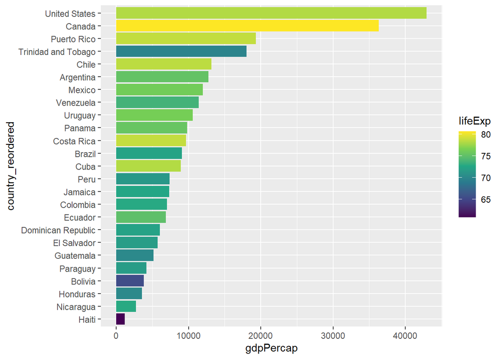

```r
plot_2007_amr
```

Now we can make use of the saved object and add things to it.

Let’s also give it a title and name the axes:

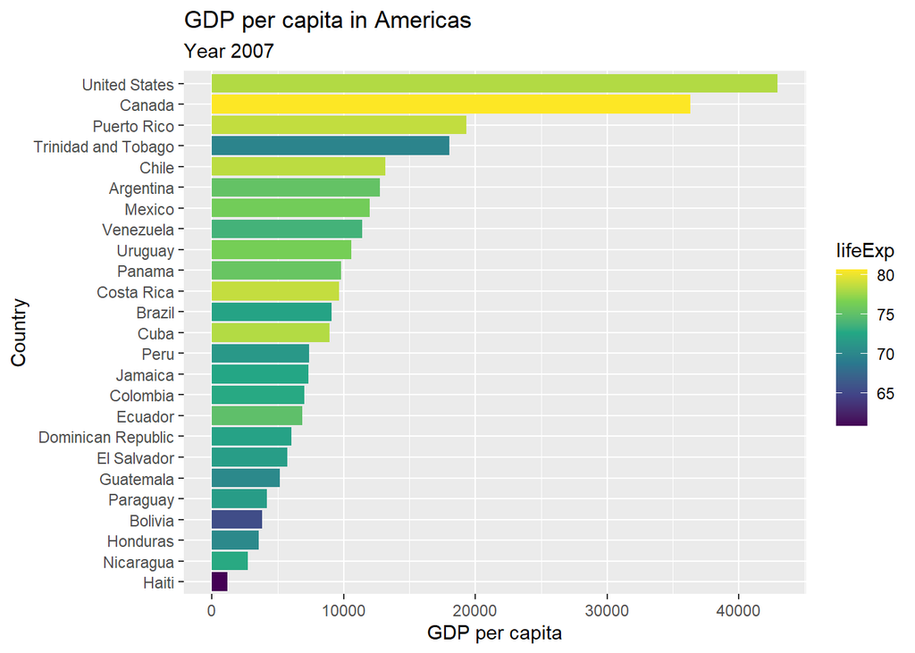

```r
plot_2007_amr <-
  plot_2007_amr +
  ggtitle('GDP per capita in Americas', subtitle = 'Year 2007') +
  xlab('Country')+
  ylab('GDP per capita')

plot_2007_amr
```

Once we are happy with our plot we can save it in a format of our choice. Remember to save it in the dedicated folder.

```r
ggsave(here('fig_output','plot_2007_amr.pdf') ) # By default, ggsave() saves the last displayed plot, but you can also explicitly name the plot you want to save
```

# [Writing Data](https://datacarpentry.org/r-intro-geospatial/08-writing-data/index.html0) (10+10 min)

Another output of your work you want to save is a cleaned dataset. In your analysis, you can then load directly that dataset. Say we want to save the data only for Australia:

```r
gapminder_aus <- gapminder %>%
  filter(country == 'Australia')

write_csv(gapminder_aus, here('data_output', 'gapminder_australia.csv'))
```